# EDA. Incidencia Delictiva por AGEB

AM_NAYELLI 84351, RD_URIEL ABRAHAM 193921, ZC_JOSE LUIS R. 183347

06/11/2021

```r
knitr::opts_chunk$set(echo = FALSE)


## ID_F0 --> This function aim to install and load libraries required.
rm(list = ls())

instalar <- function(paquete) {
  if (!require(paquete,character.only = TRUE, quietly = TRUE,
               warn.conflicts = FALSE)) {
    install.packages(as.character(paquete), dependecies = TRUE,
                     repos = "http://cran.us.r-project.org")
    library(paquete, character.only = TRUE, quietly = TRUE,
            warn.conflicts = FALSE)
  }
}

## *******   Defining required libraries to install and load   *******

## Use this vector to indicate libraries to load.
paquetes <- c("tensorflow", "keras", "tidyverse","stringi",
              "tidymodels", "glmnet", "kknn","gt","ranger")

invisible(lapply(paquetes, instalar))
```

```
## * Use tidymodels_prefer() to resolve common conflicts.
```

```r
## Load piping files and review of working libraries

source("../src/utils/utils.R", encoding = 'UTF-8')
```

### DATABASE

```
## * `` -> ...1
```

## Tidy Process

Lo primero que haremos es observar la configuración y salud de nuestros datos para iniciar el proceso de limpieza y construcción de variables derivadas relevantes para nuestro análisis.

```
## Rows: 2,397
## Columns: 65
## $ ...1                                    <dbl> 0, 1, 2, 3, 4, 5, 6, 7, 8, 9, ~
## $ CVEGEO                                  <chr> "0901000011716", "090100001215~
## $ CVE_ENT_x                               <chr> "09", "09", "09", "09", "09", ~
## $ CVE_MUN_x                               <chr> "010", "010", "010", "010", "0~
## $ CVE_LOC_x                               <chr> "0001", "0001", "0001", "0001"~
## $ CVE_AGEB_x                              <chr> "1716", "2150", "1133", "1307"~
## $ geometry                                <chr> "POLYGON ((-11049441.68989537 ~
## $ NOM_ENT                                 <chr> "Ciudad de M\u0082xico", "Ciud~
## $ NOM_MUN                                 <chr> "µlvaro Obreg¢n", "µlvaro Obre~
## $ POBTOT                                  <dbl> 7042, 4588, 2203, 2914, 237, 4~
## $ VIVTOT                                  <dbl> 1897, 1755, 857, 967, 78, 1181~
## $ TVIVHAB                                 <dbl> 1859, 1612, 769, 855, 68, 1140~
## $ P_15A17                                 <dbl> 319, 163, 53, 77, 12, 219, 94,~
```

[output cut: 52 more lines]

```
##       ...1         CVEGEO           CVE_ENT_x          CVE_MUN_x
##  Min.   :   0   Length:2397        Length:2397        Length:2397
##  1st Qu.: 599   Class :character   Class :character   Class :character
##  Median :1198   Mode  :character   Mode  :character   Mode  :character
##  Mean   :1198
##  3rd Qu.:1797
##  Max.   :2396
##
##   CVE_LOC_x          CVE_AGEB_x          geometry           NOM_ENT
##  Length:2397        Length:2397        Length:2397        Length:2397
##  Class :character   Class :character   Class :character   Class :character
##  Mode  :character   Mode  :character   Mode  :character   Mode  :character
##
##
##
##
##    NOM_MUN              POBTOT          VIVTOT        TVIVHAB        P_15A17
##  Length:2397        Min.   :    0   Min.   :   0   Min.   :   0   Min.   :  0
##  Class :character   1st Qu.: 2099   1st Qu.: 719   1st Qu.: 648   1st Qu.: 75
##  Mode  :character   Median : 3434   Median :1108   Median :1016   Median :135
##                     Mean   : 3805   Mean   :1255   Mean   :1140   Mean   :158
##                     3rd Qu.: 5019   3rd Qu.:1614   3rd Qu.:1485   3rd Qu.:217
##                     Max.   :21198   Max.   :8684   Max.   :8070   Max.   :746
##                                                                   NA's   :17
##     P_18A24         P_15A17_M        P_18A24_M        P_15A17_F
##  Min.   :   0.0   Min.   :  0.00   Min.   :   0.0   Min.   :  0.00
##  1st Qu.: 209.0   1st Qu.: 38.00   1st Qu.: 106.0   1st Qu.: 36.75
##  Median : 358.0   Median : 69.00   Median : 182.0   Median : 66.00
##  Mean   : 408.3   Mean   : 80.75   Mean   : 206.5   Mean   : 77.81
##  3rd Qu.: 547.0   3rd Qu.:112.00   3rd Qu.: 279.0   3rd Qu.:107.00
##  Max.   :1906.0   Max.   :385.00   Max.   :1538.0   Max.   :383.00
##  NA's   :14       NA's   :27       NA's   :21       NA's   :25
##    P_18A24_F          PNACOE          P15YM_AN         P15A17A
##  Min.   :   0.0   Min.   :   0.0   Min.   :  0.00   Min.   :  0.0
##  1st Qu.: 103.0   1st Qu.: 358.0   1st Qu.: 13.00   1st Qu.: 63.5
##  Median : 178.0   Median : 575.0   Median : 32.00   Median :112.0
##  Mean   : 202.4   Mean   : 694.2   Mean   : 45.89   Mean   :127.8
##  3rd Qu.: 272.0   3rd Qu.: 920.0   3rd Qu.: 65.00   3rd Qu.:174.0
##  Max.   :1006.0   Max.   :4459.0   Max.   :307.00   Max.   :617.0
##  NA's   :14       NA's   :11       NA's   :110      NA's   :18
```

[output cut: 81 more lines]

```
##  Min.   :  1.0                           Min.   : 1.000
##  1st Qu.:  1.0                           1st Qu.: 1.000
##  Median :  2.0                           Median : 2.000
##  Mean   :  7.5                           Mean   : 2.781
##  3rd Qu.:  5.0                           3rd Qu.: 3.000
##  Max.   :269.0                           Max.   :49.000
##  NA's   :1899                            NA's   :1430
##   Narcomenudeo     Robo_Casa_Sin_Violencia  Postes_Wifi
##  Min.   :  1.000   Min.   :1.000           Min.   : 1.000
##  1st Qu.:  1.000   1st Qu.:1.000           1st Qu.: 3.000
##  Median :  1.000   Median :1.000           Median : 5.000
##  Mean   :  2.744   Mean   :1.704           Mean   : 5.989
##  3rd Qu.:  3.000   3rd Qu.:2.000           3rd Qu.: 8.000
##  Max.   :114.000   Max.   :9.000           Max.   :27.000
##  NA's   :1380      NA's   :1164            NA's   :118
```

### LIMPIEZA

En relación a las variables que indican el grado de desarrollo urbano:

> vph_inter (internet), psinder (no afiliación serv. salud), vph_pisoti (piso tierra), vph_s_elec (no electricidad), vph_aguafv (no agua potable), vph_nodren (no drenaje)

al observar alta presencia de NA’s y 0’s en las últimas cuatro variables, se concluye que al ser un análisis en la CDMX tienen poca o nula variabilidad pues, aunque si existen zonas marginadas, estas no son relevantes para nuestro análisis. Por esta razón se eliminarán.

Por otro lado, las variables de servicios de internet y afiliación a servicios de salud, consideramos que sí podría existir cierto grado de relación con respecto al robo de vehículos.

Durante nuestra etapa de modelado, descubrimos que existen 17 AGEBS con POBTOT = 0 y que esto se replica en todas las variables relacionadas a población. Al revisar la variable objetivo de estas observaciones, nos percatamos que se tienen varios registros con NA, veamos:

```
## # A tibble: 17 x 39
##    POBTOT P_15A17 P_18A24 P_15A17_M P_18A24_M P_15A17_F P_18A24_F PNACOE
##     <dbl>   <dbl>   <dbl>     <dbl>     <dbl>     <dbl>     <dbl>  <dbl>
##  1      0       0       0         0         0         0         0      0
##  2      0       0       0         0         0         0         0      0
##  3      0       0       0         0         0         0         0      0
##  4      0       0       0         0         0         0         0      0
##  5      0       0       0         0         0         0         0      0
##  6      0       0       0         0         0         0         0      0
##  7      0       0       0         0         0         0         0      0
##  8      0       0       0         0         0         0         0      0
##  9      0       0       0         0         0         0         0      0
## 10      0       0       0         0         0         0         0      0
## 11      0       0       0         0         0         0         0      0
## 12      0       0       0         0         0         0         0      0
## 13      0       0       0         0         0         0         0      0
## 14      0       0       0         0         0         0         0      0
## 15      0       0       0         0         0         0         0      0
## 16      0       0       0         0         0         0         0      0
## 17      0       0       0         0         0         0         0      0
## # ... with 31 more variables: P15YM_AN <dbl>, P15A17A <dbl>, P15A17A_F <dbl>,
## #   P15A17A_M <dbl>, P18A24A <dbl>, P18A24A_F <dbl>, P18A24A_M <dbl>,
## #   PEA <dbl>, PEA_F <dbl>, PEA_M <dbl>, POCUPADA <dbl>, POCUPADA_F <dbl>,
## #   POCUPADA_M <dbl>, PDESOCUP <dbl>, PDESOCUP_F <dbl>, PDESOCUP_M <dbl>,
## #   POBHOG <dbl>, PHOGJEF_F <dbl>, PRO_OCUP_C <dbl>, PSINDER <dbl>,
## #   pop_15_24 <dbl>, pop_15_24_H <dbl>, Robo_Vehículos <dbl>,
## #   Robo_Objetos <dbl>, Robo_Objetos_Vehiculo <dbl>, Robo_Transeunte <dbl>, ...
```

por lo que podemos eliminar estos registros al no representar perdida de información siginificativa (17 de +2000)

Con el preprocesamiento anterior, se ejecutaron algunos modelos a nivel AGEB, donde uno de los principales hallazgos es que las observaciones (robo de vehículos) a este nivel son sumamente ralos, lo que dificulta un modelado adecuado.

A este punto, revisamos la información y hemos decidido que la mejor forma de ejecutar nuestro análisis es a un nivel de abstración mayor, por lo que evaluaremos nuestros modelos a nivel municipio-localidad, el cuál agrupa un conjunto de AGEBS que consideramos nos puede dar una mejor resultado.

Otro de los aspectos importantes a considerar es la recomendación de nuestro profesor sobre no estandarizar nuestras variables.

Ahora revisamos nuestros datos posterior al proceso de limpieza.

```
## Rows: 2,380
## Columns: 52
## $ robo_vehículos                          <dbl> 3, 8, 4, 7, 0, 1, 2, 0, 1, 0, ~
## $ cvegeo                                  <chr> "0901000011716", "090100001215~
## $ id_mun_loc                              <chr> "0100001", "0100001", "0100001~
## $ cve_ent_x                               <chr> "09", "09", "09", "09", "09", ~
## $ cve_mun_x                               <chr> "010", "010", "010", "010", "0~
## $ cve_loc_x                               <chr> "0001", "0001", "0001", "0001"~
## $ cve_ageb_x                              <chr> "1716", "2150", "1133", "1307"~
## $ geometry                                <chr> "POLYGON ((-11049441.68989537 ~
## $ nom_mun                                 <fct> alvaro_obregon, alvaro_obregon~
## $ pobtot                                  <dbl> 7042, 4588, 2203, 2914, 237, 4~
## $ vivtot                                  <dbl> 1897, 1755, 857, 967, 78, 1181~
## $ tvivhab                                 <dbl> 1859, 1612, 769, 855, 68, 1140~
## $ p15ym_an                                <dbl> 167, 45, 7, 14, 0, 72, 14, 0, ~
```

[output cut: 39 more lines]

```
##  [1] "robo_vehículos"
##  [2] "cvegeo"
##  [3] "id_mun_loc"
##  [4] "cve_ent_x"
##  [5] "cve_mun_x"
##  [6] "cve_loc_x"
##  [7] "cve_ageb_x"
##  [8] "geometry"
##  [9] "nom_mun"
## [10] "pobtot"
## [11] "vivtot"
## [12] "tvivhab"
## [13] "p15ym_an"
## [14] "p15a24a"
## [15] "p15a24a_f"
```

[output cut: 37 more lines]

**Imputación NA’s** Mediana en columnas numéricas distintas a matches(“^robo”)

```
## Note: Using an external vector in selections is ambiguous.
## i Use `all_of(var_numericas)` instead of `var_numericas` to silence this message.
## i See <https://tidyselect.r-lib.org/reference/faq-external-vector.html>.
```

```
## Note: Using an external vector in selections is ambiguous.
## i Use `all_of(var_categoricas)` instead of `var_categoricas` to silence this message.
## i See <https://tidyselect.r-lib.org/reference/faq-external-vector.html>.
```

```
##  robo_vehículos      cvegeo           id_mun_loc         cve_ent_x
##  Min.   : 0.000   Length:2380        Length:2380        Length:2380
##  1st Qu.: 1.000   Class :character   Class :character   Class :character
##  Median : 2.000   Mode  :character   Mode  :character   Mode  :character
##  Mean   : 2.313
##  3rd Qu.: 3.000
##  Max.   :39.000
##
##   cve_mun_x          cve_loc_x          cve_ageb_x          geometry
##  Length:2380        Length:2380        Length:2380        Length:2380
##  Class :character   Class :character   Class :character   Class :character
##  Mode  :character   Mode  :character   Mode  :character   Mode  :character
##
##
##
##
##              nom_mun        pobtot          vivtot          tvivhab
##  iztapalapa      :451   Min.   :    1   Min.   :   0.0   Min.   :   0
##  gustavo_a_madero:302   1st Qu.: 2134   1st Qu.: 725.8   1st Qu.: 654
##  tlalpan         :196   Median : 3454   Median :1115.0   Median :1024
##  alvaro_obregon  :192   Mean   : 3832   Mean   :1263.5   Mean   :1149
##  coyoacan        :156   3rd Qu.: 5032   3rd Qu.:1616.5   3rd Qu.:1488
##  cuauhtemoc      :153   Max.   :21198   Max.   :8684.0   Max.   :8070
##  (Other)         :930
##     p15ym_an        p15a24a         p15a24a_f       p15a24a_m
##  Min.   :  0.0   Min.   :   0.0   Min.   :  0.0   Min.   :   0.0
##  1st Qu.: 11.0   1st Qu.: 170.8   1st Qu.: 86.0   1st Qu.:  85.0
##  Median : 31.0   Median : 283.0   Median :141.0   Median : 142.0
##  Mean   : 44.1   Mean   : 314.0   Mean   :157.7   Mean   : 156.4
##  3rd Qu.: 64.0   3rd Qu.: 414.2   3rd Qu.:209.0   3rd Qu.: 204.0
##  Max.   :307.0   Max.   :1798.0   Max.   :813.0   Max.   :1489.0
##
##     p_15a24         p_15a24_f        p_15a24_m          pnacoe
##  Min.   :   0.0   Min.   :   0.0   Min.   :   0.0   Min.   :   0.0
##  1st Qu.: 287.0   1st Qu.: 141.0   1st Qu.: 145.0   1st Qu.: 359.0
##  Median : 494.0   Median : 243.5   Median : 249.0   Median : 576.0
##  Mean   : 566.8   Mean   : 280.2   Mean   : 286.5   Mean   : 696.0
##  3rd Qu.: 764.2   3rd Qu.: 378.2   3rd Qu.: 388.2   3rd Qu.: 922.2
##  Max.   :2627.0   Max.   :1389.0   Max.   :1632.0   Max.   :4459.0
##
```

[output cut: 57 more lines]

```
##  Min.   : 0.000             Min.   :  0.000   Min.   :0.0000
##  1st Qu.: 0.000             1st Qu.:  0.000   1st Qu.:0.0000
##  Median : 0.000             Median :  0.000   Median :1.0000
##  Mean   : 1.125             Mean   :  1.166   Mean   :0.8828
##  3rd Qu.: 1.000             3rd Qu.:  1.000   3rd Qu.:1.0000
##  Max.   :49.000             Max.   :114.000   Max.   :9.0000
##
##   postes_wifi
##  Min.   : 0.000
##  1st Qu.: 3.000
##  Median : 5.000
##  Mean   : 5.708
##  3rd Qu.: 8.000
##  Max.   :27.000
##
```

## TRANSFORMACIONES EXPERT DOMAIN

### Variables Dummy e integración variable presencia de bandas delincuenciales

Integramos información relativa a las bandas que operan en las distintas alcaldías, con el objetivo de analizar el grado de influencia que representa la presencia de alguno de estos grupos delicitivos en la zona. Fuente:

https://www.elfinanciero.com.mx/nacional/40-bandas-se-disputan-la-cdmx/

```
##  [1] alvaro_obregon         azcapotzalco           benito_juarez
##  [4] coyoacan               cuajimalpa_de_morelos  cuauhtemoc
##  [7] gustavo_a_madero       iztacalco              iztapalapa
## [10] la_magdalena_contreras miguel_hidalgo         milpa_alta
## [13] tlahuac                tlalpan                venustiano_carranza
## [16] xochimilco
## 16 Levels: alvaro_obregon azcapotzalco benito_juarez ... xochimilco
```

LISTADO DE NOMBRE DE DELEGACIONES

“alvaro_obregon”, “azcapotzalco”, “benito_juarez”, “coyoacan”, “cuajimalpa_de_morelos”, “cuauhtemoc”, “gustavo_a_madero”, “iztacalco”, “iztapalapa”, “la_magdalena_contreras”, “miguel_hidalgo”, “milpa_alta”, “tlahuac”, “tlalpan”, “venustiano_carranza”, “xochimilco”

**Bandas**

Nota para nosotros: si tenemos oportunidad, creamos una tabla relacional y creamos una sóla variable de grupo delicuencial y utilizamos la variable *dummy* d *tidymodels*

**VARIABLES ASOCIADAS -> DELITOS**

**VARIABLES ASOCIADAS -> POBLACIÓN Y VARIABLES RELATIVAS**

La variable población total “pobtot” nos permite estimar las tasas al millar de las siguientes variables:

> “psinder” población sin afiliación a servicios médicos. “p15ym_an” población analfabeta “pnacoe” población nacida en otra entidad

**VARIABLES ASOCIADAS -> ESCOLARIDAD**

Población 15 - 24 años: “p_15a24”, “p_15a24_f”, “p_15a24_m” Población 15 - 24 años que asiste a la escuela: “p15a24a”, “p15a24a_f”, “p15a24a_m” Grado promedio de escolaridad: “graproes”, “graproes_f”, “graproes_m”

> tasa al millar de población 15-24 (utilizando POBTOT), tasa al millar de población 15-24 que asiste a la escuela, grado promedio de escolaridad de la población 15-130 AÑOS

con el objetivo de determinar si estas variables son relevantes en nuestro análisis.

Se tiene valores totales y por género; con el objetivo de mantener un modelo parsimonioso, se integran las variables generales y no por género. En caso requerido solo deberán realizarse los ajustes necesarios.

**VARIABLES ASOCIADAS -> POBLACIÓN ACTIVA**

POBLACIÓN ECONOMICAMENTE ACTIVA: “pea”, “pea_f”, “pea_m” POBLACIÓN OCUPADA: “pocupada”, “pocupada_f”, “pocupada_m” POBLACIÓN DESOCUPADA: “pdesocup”, “pdesocup_f”, “pdesocup_m”

En este caso, la hipótesis es que un alto índice de población económicamente activa (PEA) no está ocupada, por lo que sería probable que se incremente la incidencia de robo vehicular. Desechamos las variables por género (pues consideramos poco significativo su aporte) y de población ocupada (pues es el complemento de desocupada, correlación).

> tasa al millar de población PEA desocupada

**VARIABLES ASOCIADAS -> HOGARES**

Una de las características detectadas en las personas que han cometido algún delito, son los hogares disfuncionales, donde reiterativamente sólo se tiene la figura materna. Intemntaremos medir esto con las variables proporcionadas en el censo referente a hogares censales y hogares censales con persona de referencia mujer (CAVEAT: no tenemos mayor información que nos permita entender la figura exacta de la mujer en esta unidad de análisis, por lo que podría ser que la variable no sea significativa)

“tothog” Total hogares censales “hogjef_f” Total hogares censales persona de referencia mujer “pobhog” Pobblación en hogares censales “phogjef_f” Pobblación en hogares censales persona de referencia mujer

**VARIABLES ASOCIADAS -> VIVIENDAS PARTICULARES**

La hipotésis aquí indica que en un lugar con alto índice de viviendas desocuodas tiende a incrementar la incidencia delictiva. Nons concentraremos únicamente en la tasa al millar de viviendas deshabitadas (vivtot-tvivhab).

“vivtot” total de viviendas “tvivhab” total de viviendas habitadas “tvivparhab” total de viviendas particulares habitadas “vivpar_des” total de viviendas particulares deshabitadas

Con relación a las siguientes dos variables, intuitivamente consideramos que una alta densidad por cuarto de vivienda así como la falta de acceso a internet puede estar relacionado con niveles altos de marginación de la población. Para evitar problemas de escalas, relativisamos “vph_inter” con respecto a viviendas particulares habitadas

“pro_ocup_c” promedio de ocupantes por cuarto en viviendas particulares ocupadas “vph_inter” viviendas particulares que disponen de internet

**VARIABLES RELATIVAS**

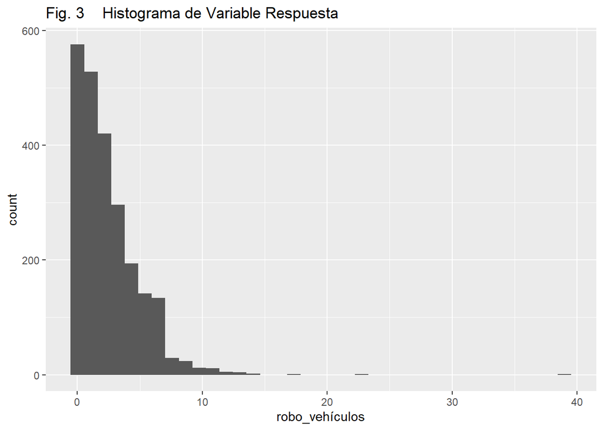

Por lo anterior, consideramos que esta variable debe ser relativa a la población observada en la AGEB, por lo que obtendremos una tasa de robo de vehiculos por cada 1,000 habitantes en la AGEB. Debemos recordar y discutir esta relación, pues un alto índice de la población carece de automóvil, por lo que sería más razonable contar con una variable que indique el número de vehículos por AGEB o la variable complementaria de número de vehículos por cada 1,000 habitantes.

Transformamos la variable obetivo:

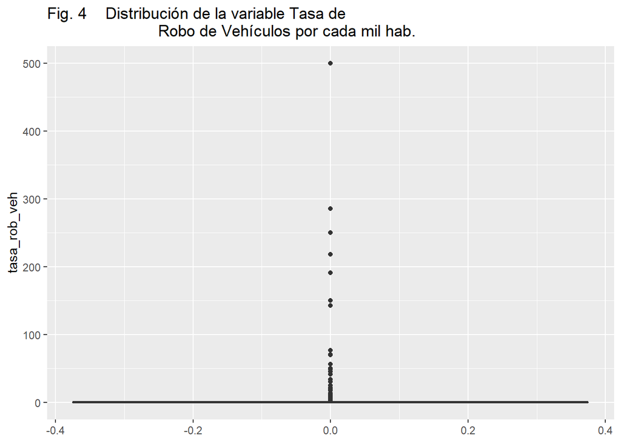

En este caso, algo en que no habíamos reparado previamente, era la alta incidencia de AGEBS con poca o nula población (derivado de posibles errores en la estimación elaborado por CENSO o simplemente por ser una zona altamente despoblada). Esto implicó tener que repensar cómo plantear nuestro modelo.

Transformar variable respuesta a factor binario:

```
##  robo_vehicular  tasa_rob_veh      robo_vehículos      cvegeo
##  No : 576       Min.   :  0.0000   Min.   : 0.000   Length:2380
##  Yes:1804       1st Qu.:  0.1259   1st Qu.: 1.000   Class :character
##                 Median :  0.4640   Median : 2.000   Mode  :character
##                 Mean   :  1.7277   Mean   : 2.313
##                 3rd Qu.:  0.9393   3rd Qu.: 3.000
##                 Max.   :500.0000   Max.   :39.000
##
##   id_mun_loc         cve_ent_x          cve_mun_x          cve_loc_x
##  Length:2380        Length:2380        Length:2380        Length:2380
##  Class :character   Class :character   Class :character   Class :character
##  Mode  :character   Mode  :character   Mode  :character   Mode  :character
##
##
##
##
##   cve_ageb_x          geometry                     nom_mun     tx1k_psinder
##  Length:2380        Length:2380        iztapalapa      :451   Min.   :   0.0
##  Class :character   Class :character   gustavo_a_madero:302   1st Qu.: 220.9
##  Mode  :character   Mode  :character   tlalpan         :196   Median : 261.5
##                                        alvaro_obregon  :192   Mean   : 264.7
##                                        coyoacan        :156   3rd Qu.: 306.5
##                                        cuauhtemoc      :153   Max.   :1000.0
##                                        (Other)         :930
##  tx1k_p15ym_an      tx1k_pnacoe     tx1k_p_15a24    tx1k_p15a24a
##  Min.   :  0.000   Min.   :  0.0   Min.   :  0.0   Min.   :   0.0
##  1st Qu.:  4.642   1st Qu.:147.0   1st Qu.:127.1   1st Qu.: 507.2
##  Median :  9.249   Median :175.9   Median :146.2   Median : 569.2
##  Mean   : 10.592   Mean   :183.7   Mean   :143.6   Mean   : 577.2
##  3rd Qu.: 14.649   3rd Qu.:210.0   3rd Qu.:162.7   3rd Qu.: 653.0
##  Max.   :181.818   Max.   :854.5   Max.   :910.3   Max.   :1000.0
##                                                    NA's   :15
##     graproes     tx1k_pea_pdesocup tx1k_hogjef_f   tx1k_phogjef_f
##  Min.   : 0.00   Min.   :  0.00    Min.   :  0.0   Min.   :  0.0
##  1st Qu.:10.39   1st Qu.: 16.94    1st Qu.:363.6   1st Qu.:337.8
##  Median :11.42   Median : 22.27    Median :402.2   Median :378.4
##  Mean   :11.71   Mean   : 22.69    Mean   :398.6   Mean   :375.8
##  3rd Qu.:13.17   3rd Qu.: 27.89    3rd Qu.:435.5   3rd Qu.:414.0
##  Max.   :16.15   Max.   :151.52    Max.   :626.1   Max.   :649.9
##                  NA's   :11        NA's   :13      NA's   :12
```

[output cut: 17 more lines]

```
##  Min.   :0.0000   Min.   :0.0000    Min.   :0.0000   Min.   :0.0000
##  1st Qu.:0.0000   1st Qu.:0.0000    1st Qu.:0.0000   1st Qu.:0.0000
##  Median :1.0000   Median :0.0000    Median :0.0000   Median :0.0000
##  Mean   :0.5996   Mean   :0.4622    Mean   :0.2803   Mean   :0.2958
##  3rd Qu.:1.0000   3rd Qu.:1.0000    3rd Qu.:1.0000   3rd Qu.:1.0000
##  Max.   :1.0000   Max.   :1.0000    Max.   :1.0000   Max.   :1.0000
##
##     rodolfos
##  Min.   :0.0000
##  1st Qu.:0.0000
##  Median :0.0000
##  Mean   :0.3013
##  3rd Qu.:1.0000
##  Max.   :1.0000
##
```

```
##  [1] "robo_vehicular"    "tasa_rob_veh"      "robo_vehículos"
##  [4] "cvegeo"            "id_mun_loc"        "cve_ent_x"
##  [7] "cve_mun_x"         "cve_loc_x"         "cve_ageb_x"
## [10] "geometry"          "nom_mun"           "tx1k_psinder"
## [13] "tx1k_p15ym_an"     "tx1k_pnacoe"       "tx1k_p_15a24"
## [16] "tx1k_p15a24a"      "graproes"          "tx1k_pea_pdesocup"
## [19] "tx1k_hogjef_f"     "tx1k_phogjef_f"    "tx1k_vivdes"
## [22] "tx1k_vph_inter"    "pro_ocup_c"        "pobtot"
## [25] "gpo_delitos1"      "gpo_delitos2"      "postes_wifi"
## [28] "union_tepito"      "cjng"              "cartel_de_tlahuac"
## [31] "lenin_canchola"    "anti_union_tepito" "rodolfos"
```

Lo primero que destacamos es que la gran mayoría de nuestras variables ya están en rangos adecuados para poder procesarlas.

Por otro lado, observemos que algunas de nuestras variables tienen presencia de Inf y NA’s que en realidad corresponden a NaN´s ocasionado por cocientes en los que nuestro denominador era 0 máqina. Estos resultados no tienen sentido pues en realidad pueden derivarse de falta de informacion recolectada en el censo errores de correspondencia entre variables. Por lo que nuestro siguiente paso será modificar estos valores enviándolos a 0.

Durante el proceso, se observó que la variable “tx1k_vph_inter” contiene tasas al millar >100k, lo cual es completamente inconsistente con la tasa. Tales Valores se imputaran con la mediana: 756.7

```
##  robo_vehicular  tasa_rob_veh      robo_vehículos      cvegeo
##  No : 576       Min.   :  0.0000   Min.   : 0.000   Length:2380
##  Yes:1804       1st Qu.:  0.1259   1st Qu.: 1.000   Class :character
##                 Median :  0.4640   Median : 2.000   Mode  :character
##                 Mean   :  1.7277   Mean   : 2.313
##                 3rd Qu.:  0.9393   3rd Qu.: 3.000
##                 Max.   :500.0000   Max.   :39.000
##
##   id_mun_loc         cve_ent_x          cve_mun_x          cve_loc_x
##  Length:2380        Length:2380        Length:2380        Length:2380
##  Class :character   Class :character   Class :character   Class :character
##  Mode  :character   Mode  :character   Mode  :character   Mode  :character
##
##
##
##
##   cve_ageb_x          geometry                     nom_mun     tx1k_psinder
##  Length:2380        Length:2380        iztapalapa      :451   Min.   :   0.0
##  Class :character   Class :character   gustavo_a_madero:302   1st Qu.: 220.9
##  Mode  :character   Mode  :character   tlalpan         :196   Median : 261.5
##                                        alvaro_obregon  :192   Mean   : 264.7
##                                        coyoacan        :156   3rd Qu.: 306.5
##                                        cuauhtemoc      :153   Max.   :1000.0
##                                        (Other)         :930
##  tx1k_p15ym_an      tx1k_pnacoe     tx1k_p_15a24    tx1k_p15a24a
##  Min.   :  0.000   Min.   :  0.0   Min.   :  0.0   Min.   :   0.0
##  1st Qu.:  4.642   1st Qu.:147.0   1st Qu.:127.1   1st Qu.: 506.1
##  Median :  9.249   Median :175.9   Median :146.2   Median : 568.6
##  Mean   : 10.592   Mean   :183.7   Mean   :143.6   Mean   : 573.5
##  3rd Qu.: 14.649   3rd Qu.:210.0   3rd Qu.:162.7   3rd Qu.: 651.9
##  Max.   :181.818   Max.   :854.5   Max.   :910.3   Max.   :1000.0
##
##     graproes     tx1k_pea_pdesocup tx1k_hogjef_f   tx1k_phogjef_f
##  Min.   : 0.00   Min.   :  0.00    Min.   :  0.0   Min.   :  0.0
##  1st Qu.:10.39   1st Qu.: 16.82    1st Qu.:363.2   1st Qu.:337.0
##  Median :11.42   Median : 22.22    Median :402.0   Median :378.1
##  Mean   :11.71   Mean   : 22.59    Mean   :396.4   Mean   :373.9
##  3rd Qu.:13.17   3rd Qu.: 27.85    3rd Qu.:435.4   3rd Qu.:413.7
##  Max.   :16.15   Max.   :151.52    Max.   :626.1   Max.   :649.9
##
```

[output cut: 17 more lines]

```
##  Min.   :0.0000   Min.   :0.0000    Min.   :0.0000   Min.   :0.0000
##  1st Qu.:0.0000   1st Qu.:0.0000    1st Qu.:0.0000   1st Qu.:0.0000
##  Median :1.0000   Median :0.0000    Median :0.0000   Median :0.0000
##  Mean   :0.5996   Mean   :0.4622    Mean   :0.2803   Mean   :0.2958
##  3rd Qu.:1.0000   3rd Qu.:1.0000    3rd Qu.:1.0000   3rd Qu.:1.0000
##  Max.   :1.0000   Max.   :1.0000    Max.   :1.0000   Max.   :1.0000
##
##     rodolfos
##  Min.   :0.0000
##  1st Qu.:0.0000
##  Median :0.0000
##  Mean   :0.3013
##  3rd Qu.:1.0000
##  Max.   :1.0000
##
```

```
##  [1] "robo_vehicular"    "tasa_rob_veh"      "robo_vehículos"
##  [4] "cvegeo"            "id_mun_loc"        "cve_ent_x"
##  [7] "cve_mun_x"         "cve_loc_x"         "cve_ageb_x"
## [10] "geometry"          "nom_mun"           "tx1k_psinder"
## [13] "tx1k_p15ym_an"     "tx1k_pnacoe"       "tx1k_p_15a24"
## [16] "tx1k_p15a24a"      "graproes"          "tx1k_pea_pdesocup"
## [19] "tx1k_hogjef_f"     "tx1k_phogjef_f"    "tx1k_vivdes"
## [22] "tx1k_vph_inter"    "pro_ocup_c"        "pobtot"
## [25] "gpo_delitos1"      "gpo_delitos2"      "postes_wifi"
## [28] "union_tepito"      "cjng"              "cartel_de_tlahuac"
## [31] "lenin_canchola"    "anti_union_tepito" "rodolfos"
```

## MODELADO

### Modelo 1: Aproximación lineal (no exitosa)

- Tamaño de la población 15-24 años (por dominio de experto sabemos que es la población que comete este tipo de delitos).
- Nivel de escolaridad de la población 15-24 años y grado promedio escolaridad
- Poblacion ocuopada
- PSINDER: personas sin servicio de salud
- phogjef_f: jefe referencia femenino
- Variables que muestran alguna característica de las viviendas particulares
- Variables que indican la presencia de otro tipo de delitos
- Cantidad de puntos de acceso a wifi

#CAVEAT: revisar tan pronto como terminemos

Observemos que las variables que estamos utilizando pueden ser agregadas (suma), por lo que su agrupación es transparente y sin mayor complicación, excepto por graproes (Grado promedio de escolaridad) y pro_ocup_c (promedio de ocupantes por cuato) las cuales momentaneamente la evaluaremos como promedio del promedio por AGEB

```
## # A tibble: 100 x 2
##      penalty mixture
##        <dbl>   <dbl>
##  1 0.00001         0
##  2 0.0000234       0
##  3 0.0000546       0
##  4 0.000127        0
##  5 0.000298        0
##  6 0.000695        0
##  7 0.00162         0
##  8 0.00379         0
##  9 0.00886         0
## 10 0.0207          0
## # ... with 90 more rows
```

```
## # A tibble: 100 x 5
##    id         mixture   penalty .metric .estimate
##    <chr>        <dbl>     <dbl> <chr>       <dbl>
##  1 validación       0 0.00001   rmse         2.15
##  2 validación       0 0.0000234 rmse         2.15
##  3 validación       0 0.0000546 rmse         2.15
##  4 validación       0 0.000127  rmse         2.15
##  5 validación       0 0.000298  rmse         2.15
##  6 validación       0 0.000695  rmse         2.15
##  7 validación       0 0.00162   rmse         2.15
##  8 validación       0 0.00379   rmse         2.15
##  9 validación       0 0.00886   rmse         2.15
## 10 validación       0 0.0207    rmse         2.15
## # ... with 90 more rows
```

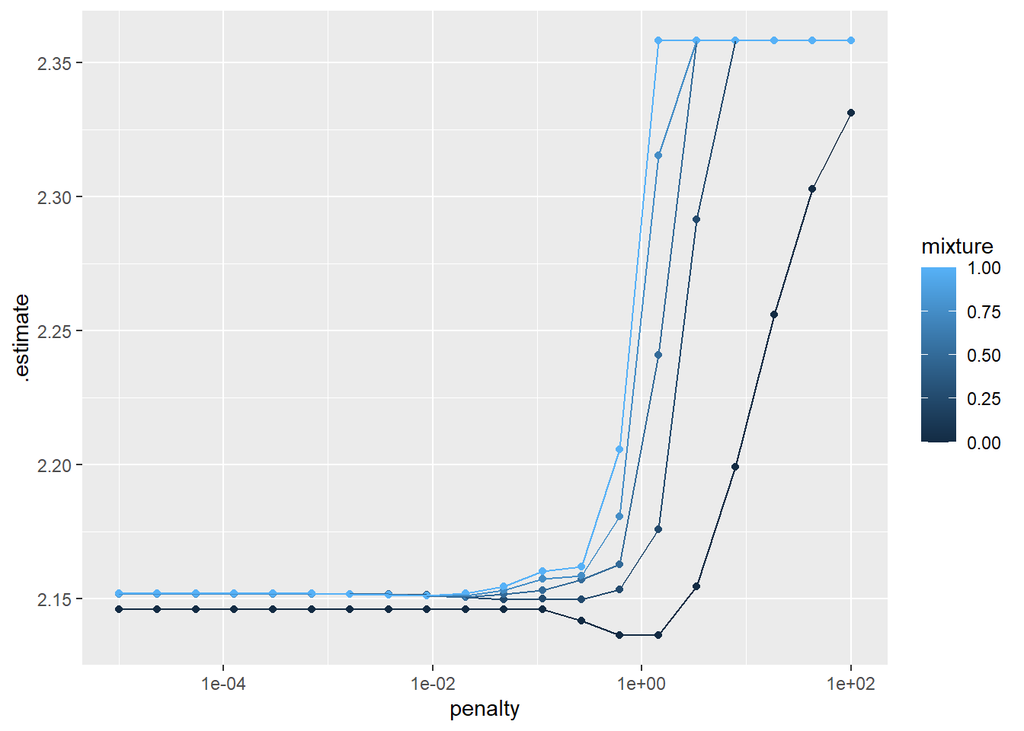

```
## # A tibble: 1 x 3
##   penalty mixture .config
##     <dbl>   <dbl> <chr>
## 1    1.44       0 Preprocessor1_Model015
```

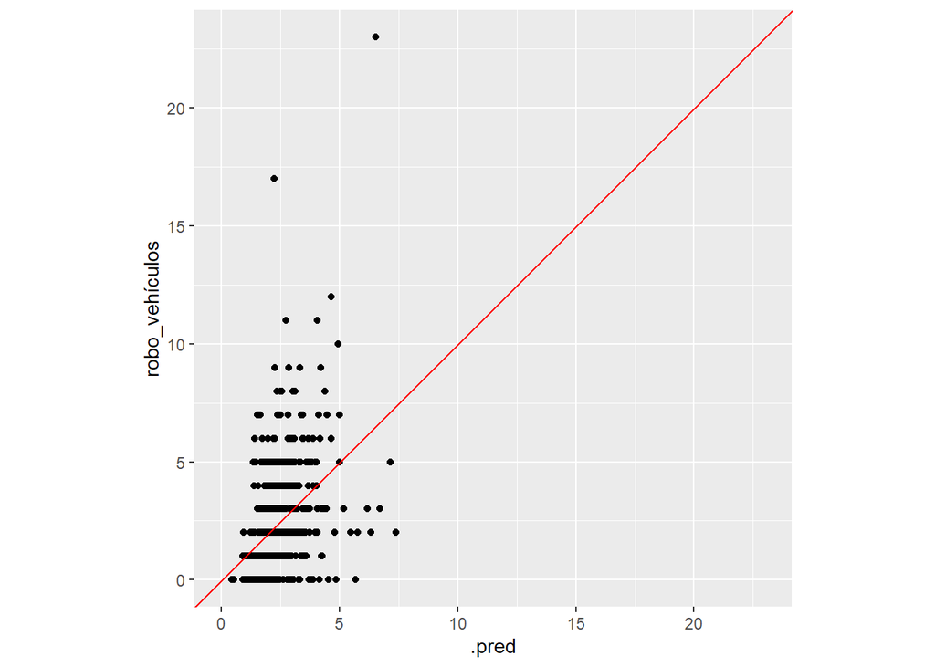

```
## # A tibble: 4 x 3
##   .metric .estimator .estimate
##   <chr>   <chr>          <dbl>
## 1 mape    standard     Inf
## 2 mae     standard       1.53
## 3 rmse    standard       2.12
## 4 rsq     standard       0.199
```

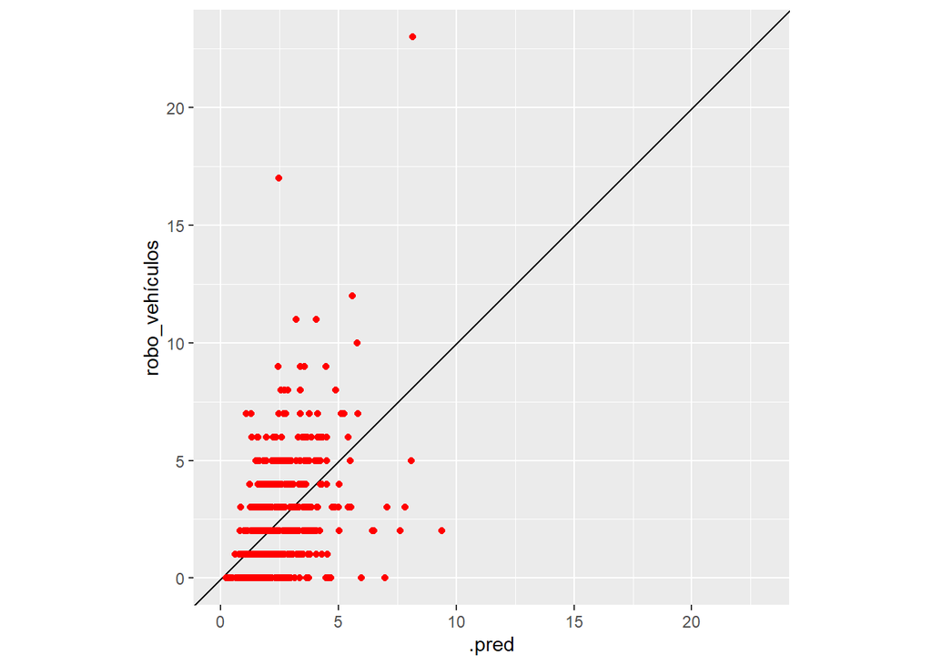

| term | estimate |
| --- | --- |
| (Intercept) | -1.193 |
| tx1k_psinder | 0.001 |
| tx1k_p15ym_an | 0.017 |
| tx1k_pnacoe | 0.001 |
| tx1k_p_15a24 | 0.000 |
| tx1k_p15a24a | 0.001 |
| graproes | 0.083 |
| tx1k_pea_pdesocup | 0.008 |
| tx1k_hogjef_f | 0.000 |
| tx1k_phogjef_f | 0.000 |
| tx1k_vivdes | -0.001 |
| tx1k_vph_inter | 0.000 |
| pro_ocup_c | -0.133 |
| gpo_delitos1 | 0.024 |
| gpo_delitos2 | 0.051 |
| postes_wifi | 0.150 |
| union_tepito | 0.439 |
| cjng | -0.006 |
| cartel_de_tlahuac | 0.280 |
| lenin_canchola | -0.139 |
| anti_union_tepito | -0.660 |
| rodolfos | 0.133 |

```
##
## Call:
## lm(formula = robo_vehículos ~ tx1k_psinder + tx1k_p15ym_an +
##     tx1k_pnacoe + tx1k_p_15a24 + tx1k_p15a24a + graproes + tx1k_pea_pdesocup +
##     tx1k_hogjef_f + tx1k_phogjef_f + tx1k_vivdes + tx1k_vph_inter +
##     pro_ocup_c + gpo_delitos1 + gpo_delitos2 + postes_wifi +
##     union_tepito + cjng + cartel_de_tlahuac + lenin_canchola +
##     anti_union_tepito + rodolfos, data = robos_entrena)
##
## Residuals:
##      Min       1Q   Median       3Q      Max
## -13.1933  -1.2911  -0.4276   0.9047  13.9216
##
## Coefficients:
##                     Estimate Std. Error t value Pr(>|t|)
## (Intercept)       -1.6905024  1.1198966  -1.510  0.13135
## tx1k_psinder       0.0004583  0.0009409   0.487  0.62628
## tx1k_p15ym_an      0.0184515  0.0082886   2.226  0.02613 *
## tx1k_pnacoe        0.0007370  0.0008794   0.838  0.40213
## tx1k_p_15a24      -0.0002474  0.0020262  -0.122  0.90283
## tx1k_p15a24a       0.0007300  0.0009138   0.799  0.42446
## graproes           0.1165652  0.0806525   1.445  0.14856
## tx1k_pea_pdesocup  0.0080559  0.0052994   1.520  0.12865
## tx1k_hogjef_f     -0.0006085  0.0024881  -0.245  0.80682
## tx1k_phogjef_f     0.0006050  0.0023792   0.254  0.79929
## tx1k_vivdes       -0.0012416  0.0009752  -1.273  0.20315
## tx1k_vph_inter    -0.0003159  0.0007697  -0.410  0.68155
## pro_ocup_c        -0.0708539  0.5365248  -0.132  0.89495
## gpo_delitos1       0.0225561  0.0068531   3.291  0.00102 **
## gpo_delitos2       0.0535110  0.0033963  15.756  < 2e-16 ***
## postes_wifi        0.1592186  0.0155729  10.224  < 2e-16 ***
## union_tepito       0.7508728  0.2611623   2.875  0.00409 **
## cjng              -0.0754006  0.1409310  -0.535  0.59271
## cartel_de_tlahuac  0.5604435  0.2390818   2.344  0.01918 *
## lenin_canchola    -0.3315733  0.1926738  -1.721  0.08544 .
## anti_union_tepito -0.7746362  0.1409044  -5.498 4.41e-08 ***
## rodolfos           0.0909269  0.1452922   0.626  0.53151
## ---
## Signif. codes:  0 '***' 0.001 '**' 0.01 '*' 0.05 '.' 0.1 ' ' 1
##
## Residual standard error: 2.073 on 1763 degrees of freedom
## Multiple R-squared:  0.337,  Adjusted R-squared:  0.3291
## F-statistic: 42.68 on 21 and 1763 DF,  p-value: < 2.2e-16
```